Data analysis Florian Leprevost 21/11/2019

# 1. Objectives

List of data wrangling and analysis to do:

# 2. Dataframe

Need the tidyverse

```r
library(tidyverse)
```

## 2.1 SART files (.xpd)

Read xpd with function from documentation

```r
#setwd('C:/Users/install/SART_PCBS')
source('expyriment_data.R')
```

Read and add difficulty

```r
dtf_sart_easy= read.expyriment.data("data", "SART_task_easy")
dtf_sart_normal= read.expyriment.data("data", "SART_task_0")

#add difficulty
dtf_sart_easy <- dtf_sart_easy %>%
  mutate(difficulty=0)
dtf_sart_normal <- dtf_sart_normal %>%
  mutate(difficulty=1)
```

Join

```r
dtf_sart = bind_rows(dtf_sart_easy, dtf_sart_normal)
glimpse(dtf_sart)
```

```
## Observations: 1,120
## Variables: 7
## $ subject_id <int> 1, 1, 1, 1, 1, 1, 1, 1, 1, 1, 1, 1, 1, 1, 1, 1, 1, 1, 1,...
## $ digit      <int> 0, 1, 2, 3, 4, 5, 6, 7, 8, 9, 0, 1, 2, 3, 4, 5, 6, 7, 8,...
## $ btn        <int> 32, 32, 32, NA, 32, 32, 32, 32, 32, 32, 32, 32, 32, 32, ...
## $ rt         <int> 374, 213, 218, NA, 23, 240, 204, 250, 250, 479, 325, 211...
## $ error      <int> 0, 0, 0, 0, 0, 0, 0, 0, 0, 0, 0, 0, 0, 1, 0, 0, 0, 0, 0,...
## $ block_name <fct> practice, practice, practice, practice, practice, practi...
## $ difficulty <dbl> 0, 0, 0, 0, 0, 0, 0, 0, 0, 0, 0, 0, 0, 0, 0, 0, 0, 0, 0,...
```

## 2.2 Probes files (.txt)

Change txt files (probe data) in csv before transforming them in dataframes

```r
files <- list.files(pattern="*.txt")
newfiles <- gsub(".txt$", ".csv", files)
file.rename(files, newfiles)
```

```
## logical(0)
```

```r
#get file names
files= list.files(pattern=".csv$")
files_easy = grep("^probe_data_easy", files, value=T)
files_normal = grep("^probe_data_easy", files, value=T, invert=T)
```

Tried the following complicated method but it didn’t work

```r
#get the difficulty indice and the subject id
difficulty=list()
subject_id=list()

for (el in files) {
  if (substr(el, 12,15) == "easy")  {
    difficulty[length(difficulty)+1]=0
    subject_id[length(subject_id)+1]=substr(el, 16,16)

  }else{
    difficulty[length(difficulty)+1]=1
    subject_id[length(subject_id)+1]=substr(el, 11,11)
  }
}

#read files
several_dtf = lapply(files, read.csv)
#add missing parameters to dataframes
for (ind in length(several_dtf)){
  several_dtf[ind] <- several_dtf[ind] %>%
    mutate("subject_id"=pull(subject_id[ind])) %>%
    mutate("difficulty"=pull(difficulty[ind]))
}
#bind dataframes
dtf_probes = do.call(rbind, several_dtf)
```

So i cheated a little, using the fact that the subject’s files are in order. I indeed used the .id parameter to re-generate subject_id. Then I used mutate to add difficulty

```r
#add subject-id
several_dtf_easy = lapply(files_easy, read.csv)
dtf_probes_easy= bind_rows(several_dtf_easy, .id= "subject_id")

several_dtf_normal = lapply(files_normal, read.csv)
dtf_probes_normal= bind_rows(several_dtf_normal, .id= "subject_id")

#add difficulty
dtf_probes_easy <- dtf_probes_easy %>%
  mutate(difficulty=0)
dtf_probes_normal <- dtf_probes_normal %>%
  mutate(difficulty=1)

#join
dtf_probes = bind_rows(dtf_probes_easy, dtf_probes_normal)

#preview
glimpse(dtf_probes)
```

```
## Observations: 28
## Variables: 8
## $ subject_id   <chr> "1", "1", "1", "1", "1", "1", "1", "2", "2", "2", "2",...
## $ block_number <fct> practice, real1, real1, real1, real1, real1, real1, pr...
## $ trial_number <int> 9, 27, 70, 96, 168, 192, 254, 6, 11, 78, 106, 156, 186...
## $ relatedness  <int> 53, 55, 55, 55, 50, 55, 53, 54, 51, 56, 56, 55, 49, 55...
## $ rt_rel       <int> 8644, 7113, 5995, 12069, 5362, 4934, 3884, 29951, 5027...
## $ control      <int> 51, 53, 55, 53, 57, 52, 56, 52, 50, 57, 49, 55, 50, 51...
## $ rt_con       <int> 3781, 2571, 6244, 2263, 1730, 2361, 1320, 3544, 1417, ...
## $ difficulty   <dbl> 0, 0, 0, 0, 0, 0, 0, 0, 0, 0, 0, 0, 0, 0, 1, 1, 1, 1, ...
```

Simple method to transform the keys into numbers

```r
#create some kind of dictionnary
dico= 1:9
names(dico)=49:57
#transform into numbers
dtf_probes <- dtf_probes %>%
  mutate(relatedness= dico[as.character(relatedness)]) %>%
  mutate(control=dico[as.character(control)])

glimpse(dtf_probes)
```

```
## Observations: 28
## Variables: 8
## $ subject_id   <chr> "1", "1", "1", "1", "1", "1", "1", "2", "2", "2", "2",...
## $ block_number <fct> practice, real1, real1, real1, real1, real1, real1, pr...
## $ trial_number <int> 9, 27, 70, 96, 168, 192, 254, 6, 11, 78, 106, 156, 186...
## $ relatedness  <int> 5, 7, 7, 7, 2, 7, 5, 6, 3, 8, 8, 7, 1, 7, 6, 7, 3, 2, ...
## $ rt_rel       <int> 8644, 7113, 5995, 12069, 5362, 4934, 3884, 29951, 5027...
## $ control      <int> 3, 5, 7, 5, 9, 4, 8, 4, 2, 9, 1, 7, 2, 3, 6, 5, 3, 2, ...
## $ rt_con       <int> 3781, 2571, 6244, 2263, 1730, 2361, 1320, 3544, 1417, ...
## $ difficulty   <dbl> 0, 0, 0, 0, 0, 0, 0, 0, 0, 0, 0, 0, 0, 0, 1, 1, 1, 1, ...
```

## 2.3 Get rtv in dtf probes

```r
indices = -8:-1

list_mean=list()
list_rtv=list()

for (probe in 1:nrow(dtf_probes))
{
  #I realised I didn't control the first probe is not after 8 trials
  if (dtf_probes$trial_number[probe] >= 8)
  {
    data_interest <- dtf_sart %>%
      filter(subject_id==dtf_probes$subject_id[probe],
             block_name==dtf_probes$block_number[probe],
             difficulty ==dtf_probes$difficulty[probe])

    eight_trials=dtf_probes$trial_number[probe] + indices
    mean_rt = mean(data_interest$rt[eight_trials], na.rm=T)
    rtv= sd(data_interest$rt[eight_trials], na.rm=T)
  }
  else {
    mean_rt=as.numeric(NA)
    rtv=as.numeric(NA)
  }
  list_mean = c(list_mean, mean_rt)
  list_rtv = c(list_rtv,rtv)
}

#add it in dataframe
dtf_probes$mean_RT = unlist(list_mean)
dtf_probes$RTV = unlist(list_rtv)
```

# 3.EDA

## EDA Plots

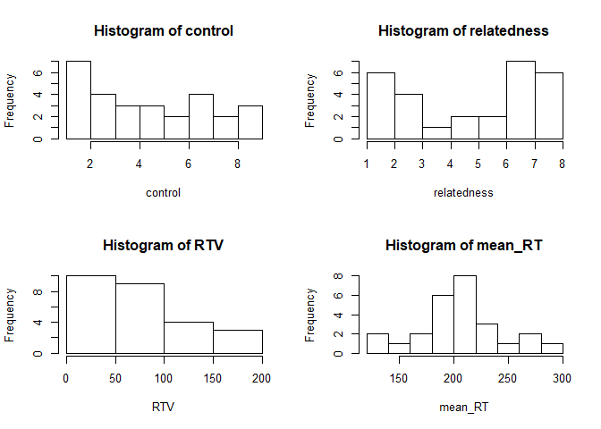

```r
attach(dtf_probes)
par(mfrow=c(2,2))
hist(control)
hist(relatedness)
hist(RTV)
hist(mean_RT)
```

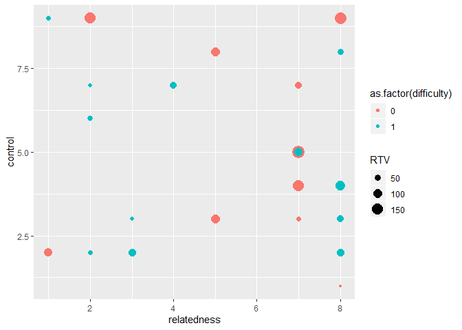

```r
detach(dtf_probes)


ggplot(dtf_probes, aes(x=relatedness, y=control, size=RTV, color= as.factor(difficulty)))+
  geom_point()
```

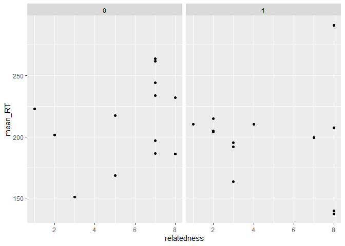

```r
ggplot(dtf_probes, aes(x=relatedness, y=mean_RT))+
  geom_point()+
  facet_wrap(~ difficulty)
```

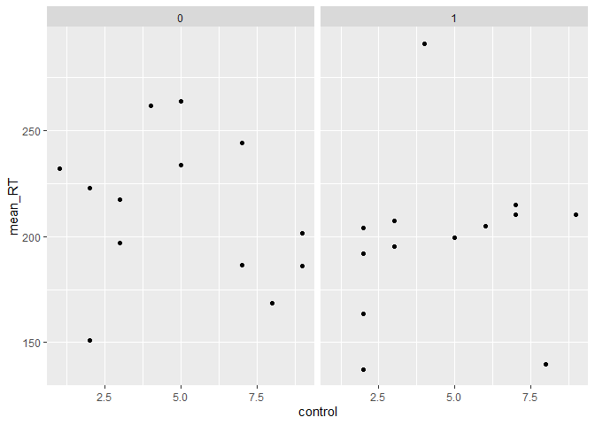

```r
ggplot(dtf_probes, aes(x=control, y=mean_RT))+
  geom_point()+
  facet_wrap(~ difficulty)
```

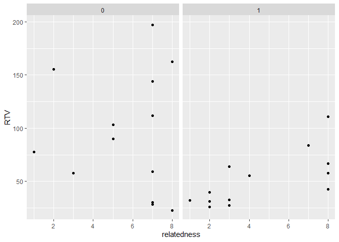

```r
ggplot(dtf_probes, aes(x=relatedness, y=RTV))+
  geom_point()+
  facet_wrap(~ difficulty)
```

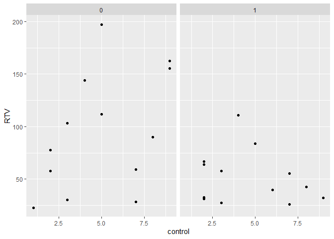

```r
ggplot(dtf_probes, aes(x=control, y=RTV))+
  geom_point()+
  facet_wrap(~ difficulty)
```

The plots seem to indicate several things - control and relatedness seem independent - RTV seem predicted by relatedness (especially in the normal difficulty condition) - RTV seem larger in the easy difficulty condition -

# 3.2 Basics stats

We can follow with some statistical tests (I know the data is not normal, but I don’t really know about the alternative, so this is just some ideas)

```r
#independence of control and relatedness
chisq.test(dtf_probes$control, dtf_probes$relatedness)
```

```
##
##  Pearson's Chi-squared test
##
## data:  dtf_probes$control and dtf_probes$relatedness
## X-squared = 59.556, df = 56, p-value = 0.3476
```

Linear regressions

```r
summary(lm(RTV~ control+relatedness+difficulty, dtf_probes))
```

```
##
## Call:
## lm(formula = RTV ~ control + relatedness + difficulty, data = dtf_probes)
##
## Residuals:
##    Min     1Q Median     3Q    Max
## -79.63 -22.54  -2.08  21.25  97.19
##
## Coefficients:
##             Estimate Std. Error t value Pr(>|t|)
## (Intercept)   55.219     28.784   1.918   0.0681 .
## control        4.015      3.333   1.205   0.2411
## relatedness    3.534      3.448   1.025   0.3165
## difficulty   -38.255     17.507  -2.185   0.0398 *
## ---
## Signif. codes:  0 '***' 0.001 '**' 0.01 '*' 0.05 '.' 0.1 ' ' 1
##
## Residual standard error: 43.32 on 22 degrees of freedom
##   (2 observations deleted due to missingness)
## Multiple R-squared:  0.2924, Adjusted R-squared:  0.196
## F-statistic: 3.031 on 3 and 22 DF,  p-value: 0.05088
```

Only **difficulty** is a significant predictor of RTV.

```r
summary(lm(mean_RT~ control+relatedness+difficulty, dtf_probes))
```

```
##
## Call:
## lm(formula = mean_RT ~ control + relatedness + difficulty, data = dtf_probes)
##
## Residuals:
##     Min      1Q  Median      3Q     Max
## -66.245 -24.666   4.302  18.205  88.665
##
## Coefficients:
##             Estimate Std. Error t value Pr(>|t|)
## (Intercept) 208.5784    25.2885   8.248 3.54e-08 ***
## control      -0.5709     2.9283  -0.195    0.847
## relatedness   1.2569     3.0292   0.415    0.682
## difficulty  -13.8718    15.3804  -0.902    0.377
## ---
## Signif. codes:  0 '***' 0.001 '**' 0.01 '*' 0.05 '.' 0.1 ' ' 1
##
## Residual standard error: 38.06 on 22 degrees of freedom
##   (2 observations deleted due to missingness)
## Multiple R-squared:  0.05333,    Adjusted R-squared:  -0.07576
## F-statistic: 0.4131 on 3 and 22 DF,  p-value: 0.7452
```

Nothing

```r
summary(lm(RTV~ control*difficulty, dtf_probes))
```

```
##
## Call:
## lm(formula = RTV ~ control * difficulty, data = dtf_probes)
##
## Residuals:
##     Min      1Q  Median      3Q     Max
## -84.558 -25.178   0.385  22.739 101.812
##
## Coefficients:
##                    Estimate Std. Error t value Pr(>|t|)
## (Intercept)          51.473     24.682   2.085   0.0488 *
## control               8.788      4.358   2.016   0.0561 .
## difficulty            8.943     35.021   0.255   0.8008
## control:difficulty  -10.712      6.455  -1.660   0.1112
## ---
## Signif. codes:  0 '***' 0.001 '**' 0.01 '*' 0.05 '.' 0.1 ' ' 1
##
## Residual standard error: 41.8 on 22 degrees of freedom
##   (2 observations deleted due to missingness)
## Multiple R-squared:  0.3412, Adjusted R-squared:  0.2513
## F-statistic: 3.797 on 3 and 22 DF,  p-value: 0.02467
```

But with only difficulty and control (and their interaction effect), control is almost a significant predictor of RTV.

## 3.3 Reproduce Seli’s

Reshape data to match

```r
data_seli <- dtf_probes %>%
  mutate(intention=ifelse(control>4, "deliberate", "spontaneous")) %>%
  mutate(on_off= ifelse(relatedness<6, "off", "on"))
```

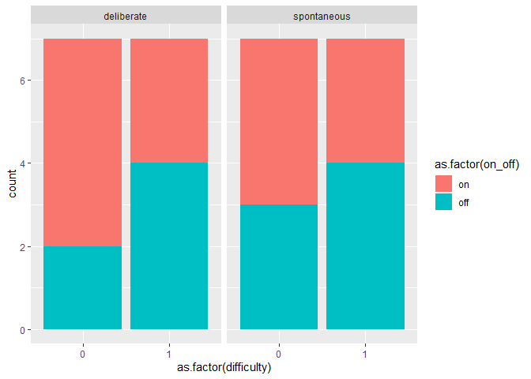

```r
#switch on_off order

data_seli$on_off <- factor(data_seli$on_off, levels = c("on", "off"))

#plot
ggplot(data_seli, aes(x=as.factor(difficulty), fill=as.factor(on_off)))+
  geom_bar()+
  facet_grid(~ intention)
```

Not really reproduced: both deliberate and spontaneous mindwandering increase with difficulty

# 4. Conclusion

I would have like to try more analysis, but I lack time, and it wouldn’t be much interesting with as little data anyway. I still feel I learned a lot by doing such a big project, from the conception of the experiment to automatizing the data analysis.